# R’da Dağılımlar, Hipotez Testleri, ANOVA, EKK

# 1 t-Testleri

İki popülasyon ortalaması arasındaki farkı hızlı bir şekilde anlamak için genellikle t testini kullanırız.

Örneklemlerin yeterince büyük olmasını (yani, her iki örneklemin de 20 veya daha fazla gözlemi olması) veya temeldeki popülasyonların normal olarak dağılmasını gerektirir.

“Normal dağılmış” kısmını tam anlamıyla almayız. Çan şeklinde veya makul ölçüde simetrik olması yeterlidir.

## 1.1 Tek Örneklem t-Testi

Aşağıdaki verilere sahip olduğumuzu varsayalım:

```r
library(tidyverse)
data(tips, package = "reshape2")
glimpse(tips)
```

```
## Rows: 244
## Columns: 7
## $ total_bill <dbl> 16.99, 10.34, 21.01, 23.68, 24.59, 25.29, 8.77, 26.88, 15.0…
## $ tip        <dbl> 1.01, 1.66, 3.50, 3.31, 3.61, 4.71, 2.00, 3.12, 1.96, 3.23,…
## $ sex        <fct> Female, Male, Male, Male, Female, Male, Male, Male, Male, M…
## $ smoker     <fct> No, No, No, No, No, No, No, No, No, No, No, No, No, No, No,…
## $ day        <fct> Sun, Sun, Sun, Sun, Sun, Sun, Sun, Sun, Sun, Sun, Sun, Sun,…
## $ time       <fct> Dinner, Dinner, Dinner, Dinner, Dinner, Dinner, Dinner, Din…
## $ size       <int> 2, 3, 3, 2, 4, 4, 2, 4, 2, 2, 2, 4, 2, 4, 2, 2, 3, 3, 3, 3,…
```

Ortalama bahşişin 2,50 dolara eşit olup olmadığına dair tek örneklem t testi yapalım.

```r
t.test(tips$tip, alternative = "two.sided", mu = 2.5)
```

```
##
##  One Sample t-test
##
## data:  tips$tip
## t = 5.6253, df = 243, p-value = 5.08e-08
## alternative hypothesis: true mean is not equal to 2.5
## 95 percent confidence interval:
##  2.823799 3.172758
## sample estimates:
## mean of x
##  2.998279
```

p değeri, boş hipotezin reddedilmesi gerektiğini gösterir ve ortalamanın 2,50 ABD Dolarına eşit olmadığı sonucuna varırız.

Ortalamanın 2,50 dolardan büyük olup olmadığını görmek için başka bir tek taraflı t testi yapalım.

```r
t.test(tips$tip, alternative = "greater", mu = 2.50)
```

```
##
##  One Sample t-test
##
## data:  tips$tip
## t = 5.6253, df = 243, p-value = 2.54e-08
## alternative hypothesis: true mean is greater than 2.5
## 95 percent confidence interval:
##  2.852023      Inf
## sample estimates:
## mean of x
##  2.998279
```

Bir kez daha, p değeri, sıfır hipotezini reddetmemiz ve ortalamanın 2,50 ABD Dolarından büyük olduğu sonucuna varmamız gerektiğini gösterir.

## 1.2 İki Örneklem t-Testi

Kadın ve erkek müşterilerin nasıl bahşiş verdiğini karşılaştıralım.

Bununla birlikte, t-testini çalıştırmadan önce, her bir örneklemin varyansını kontrol etmemiz gerekir.

Geleneksel bir t testi her iki grubun da aynı varyansa sahip olmasını gerektirirken, Welch iki örneklemli t testi farklı varyanslara sahip grupları için kullanılabilir.

```r
library(broom)

tips %>%
  group_by(sex) %>%
  summarise(var = var(tip))
```

```
## # A tibble: 2 × 2
##   sex      var
##   <fct>  <dbl>
## 1 Female  1.34
## 2 Male    2.22
```

```r
# Normallik Testi
shapiro.test(tips$tip)
```

```
##
##  Shapiro-Wilk normality test
##
## data:  tips$tip
## W = 0.89781, p-value = 8.2e-12
```

```r
# p > 0.05 not normal

tips %>%
  group_by(sex) %>%
  nest() %>%
  mutate(Shapiro = map(data, ~shapiro.test(.x$tip))) %>%
  mutate(glance_shapiro = Shapiro %>% map(glance)) %>%
  unnest(glance_shapiro) %>%
  select(sex, statistic, p.value)
```

```
## # A tibble: 2 × 3
## # Groups:   sex [2]
##   sex    statistic  p.value
##   <fct>      <dbl>    <dbl>
## 1 Female     0.957 5.45e- 3
## 2 Male       0.876 3.71e-10
```

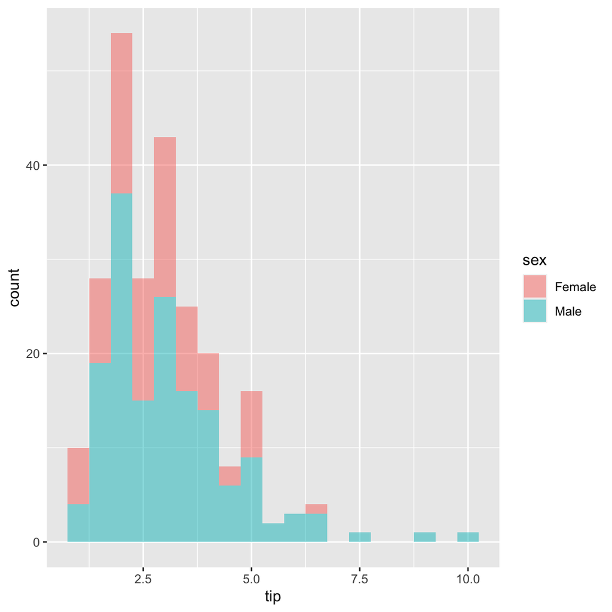

```r
# p > 0.05 not normal

# Tüm testler başarısız olduğundan görsel olarak inceleyelim
ggplot(tips) +
  aes(x = tip, fill = sex) +
  geom_histogram(binwidth = .5, alpha = 0.5)
```

Veriler normal olarak dağılmış görünmüyor. Varyansların eşitliğini incelemek için parametrik olmayan Ansari-Bradley testini kullanalım.

```r
ansari.test(tip ~ sex, tips)
```

```
##
##  Ansari-Bradley test
##
## data:  tip by sex
## AB = 5582.5, p-value = 0.376
## alternative hypothesis: true ratio of scales is not equal to 1
```

Bu test, varyansların eşit olduğunu gösterir, yani standart iki örneklem t-testini kullanabiliriz.

`var.equal = TRUE` argümanının ayarlanması, standart iki örnek t-testi çalıştırır ve `var.equal = FALSE` (varsayılan) Welch testini çalıştırır.

```r
t.test(tip ~ sex, data = tips, var.equal = TRUE)
```

```
##
##  Two Sample t-test
##
## data:  tip by sex
## t = -1.3879, df = 242, p-value = 0.1665
## alternative hypothesis: true difference in means between group Female and group Male is not equal to 0
## 95 percent confidence interval:
##  -0.6197558  0.1074167
## sample estimates:
## mean in group Female   mean in group Male
##             2.833448             3.089618
```

Sonuçlar anlamlı değildir. Kadın ve erkek müşterilerin aşağı yukarı eşit şekilde bahşiş bıraktıkları sonucuna varabiliriz.

## 1.3 Eşleştirilmiş İki Örneklem t-Testi

Eşleştirilmiş verileri test etmek için (örneğin, ikizler üzerindeki ölçümler, tedavi öncesi ve sonrası etkiler, baba ve oğul karşılaştırmaları) eşleştirilmiş bir t-testi kullanılmalıdır.

Babaların ve oğulların boylarıyla ilgili verileri kullanalım. Boy verileri genellikle normal olarak dağılır, bu nedenle normallik ve eşit varyans testlerini yapmadan devam edelim.

```r
data(father.son, package = "UsingR")
t.test(father.son$fheight, father.son$sheight, paired = TRUE)
```

```
##
##  Paired t-test
##
## data:  father.son$fheight and father.son$sheight
## t = -11.789, df = 1077, p-value < 2.2e-16
## alternative hypothesis: true difference in means is not equal to 0
## 95 percent confidence interval:
##  -1.1629160 -0.8310296
## sample estimates:
## mean of the differences
##              -0.9969728
```

Bu test, boş hipotezi reddetmemiz ve babaların ve oğulların farklı boylara sahip olduğu sonucuna varmamız gerektiğini gösteriyor.

## 1.4 Eşit Oranlar için Grupların Testi

İki veya daha fazla gruptan örnek aldığımızı varsayalım. Grupların öğeleri başarı veya başarısızlık şeklinde ikili değerlidir. Grupların eşit başarı oranlarına sahip olup olmadığını bilmek istediğimizi varsayalım.

Nilay 38 öğrenciye istatistik öğretmiş ve 14 öğrenciye A notu vermiş olsun. Emrah aynı dersi 40 öğrenciye öğretmiş ve sadece 10 kişiye A vermiş olsun. “Nilay, Emrah’dan çok daha fazla A notu vererek not enflasyonunu teşvik ediyor mu?” sorusuna cevap arayalım.

```r
# Nilay & Emrah'ın verdiği A'lar
successes <- c(14, 10)

# Öğrenci Sayıları
trials <- c(38, 40)

# Test
prop.test(successes, trials)
```

```
##
##  2-sample test for equality of proportions with continuity correction
##
## data:  successes out of trials
## X-squared = 0.7872, df = 1, p-value = 0.3749
## alternative hypothesis: two.sided
## 95 percent confidence interval:
##  -0.1110245  0.3478666
## sample estimates:
##    prop 1    prop 2
## 0.3684211 0.2500000
```

Nispeten büyük p-değeri, sıfır hipotezini reddedemeyeceğimiz anlamına gelir: kanıtlar, Nilay’ın ve Emrah’ın notlandırmaları arasında herhangi bir fark olduğunu göstermez.

## 1.5 Grup Ortalamaları Arasında İkili Karşılaştırmalar

Birkaç örneklemimiz olduğunu ve örneklem ortalamaları arasında ikili bir karşılaştırma yapmak istediğimizi varsayalım.

Yani, her örneklemin ortalamasını diğer örneklemin ortalamasıyla karşılaştırmak istiyoruz.

```r
library(rstatix)

data("PlantGrowth")
glimpse(PlantGrowth)
```

```
## Rows: 30
## Columns: 2
## $ weight <dbl> 4.17, 5.58, 5.18, 6.11, 4.50, 4.61, 5.17, 4.53, 5.33, 5.14, 4.8…
## $ group  <fct> ctrl, ctrl, ctrl, ctrl, ctrl, ctrl, ctrl, ctrl, ctrl, ctrl, trt…
```

```r
PlantGrowth %>%
  count(group)
```

```
##   group  n
## 1  ctrl 10
## 2  trt1 10
## 3  trt2 10
```

```r
# ?pairwise_t_test
PlantGrowth %>%
  pairwise_t_test(weight ~ group,
                  pool.sd = FALSE,
                  p.adjust.method = "bonferroni")
```

```
## # A tibble: 3 × 10
##   .y.    group1 group2    n1    n2 statistic    df     p p.adj p.adj.signif
## * <chr>  <chr>  <chr>  <int> <int>     <dbl> <dbl> <dbl> <dbl> <chr>
## 1 weight ctrl   trt1      10    10      1.19  16.5 0.25  0.75  ns
## 2 weight ctrl   trt2      10    10     -2.13  16.8 0.048 0.144 ns
## 3 weight trt1   trt2      10    10     -3.01  14.1 0.009 0.028 *
```

Bununla birlikte, `ctrl` ile `trt1` arasındaki karşılaştırma, 0.25’lik büyük bir p değeri üretmiştir, bu nedenle önemli ölçüde farklı değiller diyebiliriz.

## 1.6 İki Örneklemin Aynı Dağılımdan Olup Olmadığının Test Edilmesi

Diyelim ki iki örneklemiz var ve bunların aynı dağılımdan gelip gelmediğini merak ediyoruz.

Kolmogorov-Smirnov testi iki örneklemi karşılaştırır ve aynı dağılımdan gelip gelmediğini test eder.

KS parametrik olmayan bir testtir ve bu nedenle temel dağılımlarla ilgili herhangi bir varsayımda bulunmamıza gerek yoktur.

KS, örneklemlere dayalı olarak popülasyonların konumunu, dağılımını ve şeklini kontrol eder. Bu özellikler uyuşmuyorsa, test bunu tespit edecek ve temel dağılımların farklı olduğu sonucuna varmanızı sağlayacaktır.

Aşağıdaki verilere sahip olduğumuzu varsayalım. Saf bir şekilde iki örneğin bağımsız olduğunu varsayarsak, örnekler aynı puan popülasyonundan mı diye test edelim.

```r
data(stud.recs, package = "UsingR")
glimpse(stud.recs)
```

```
## Rows: 160
## Columns: 7
## $ seq.1        <dbl> 80, 74, 84, 85, 81, 81, 68, 65, 65, 89, 79, 77, 74, 69, 3…
## $ seq.2        <dbl> 47, 76, 85, 88, 75, 71, 54, 80, 43, 65, 74, 85, 81, 71, 7…
## $ seq.3        <dbl> 76, 81, 90, 68, 66, 67, 72, 65, 34, 65, 32, 69, 81, 78, 6…
## $ sat.v        <dbl> 440, 410, 610, 300, 550, 460, 410, 480, 480, 360, 390, 50…
## $ sat.m        <dbl> 450, 480, 590, 520, 560, 400, 430, 460, 510, 380, 500, 52…
## $ letter.grade <fct>  B  ,  B- ,  D  ,  A  ,  A  ,  C  ,  D  ,  C  ,  A  ,  WU…
## $ num.grade    <dbl> 3.0, 2.7, 1.0, 4.0, 4.0, 2.0, 1.0, 2.0, 4.0, 0.0, 3.0, 2.…
```

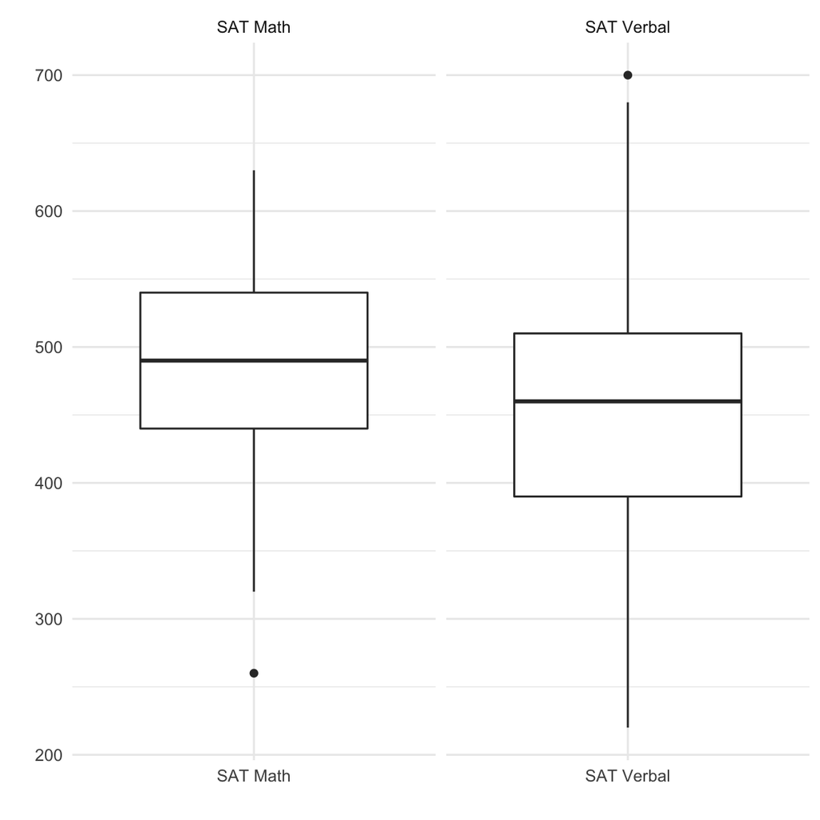

```r
dt <- stud.recs %>%
  select(sat.m, sat.v) %>%
  magrittr::set_colnames(c("SAT Math", "SAT Verbal")) %>%
  pivot_longer(everything(),
               names_to = "var",
               values_to = "val")
dt %>%
  GGally::ggally_box(mapping = ggplot2::aes(x = var, y = val)) +
  labs(x = "", y = "") +
  theme_minimal()
```

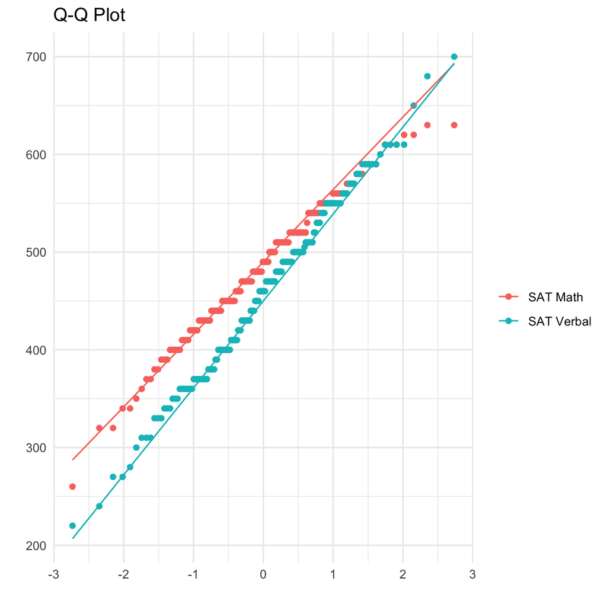

```r
dt %>%
  ggplot() +
  stat_qq(aes(sample = val, color = var)) +
  stat_qq_line(aes(sample = val, color = var)) +
  labs(x = "", y = "", color = "",
       title = "Q-Q Plot") +
  theme_minimal()
```

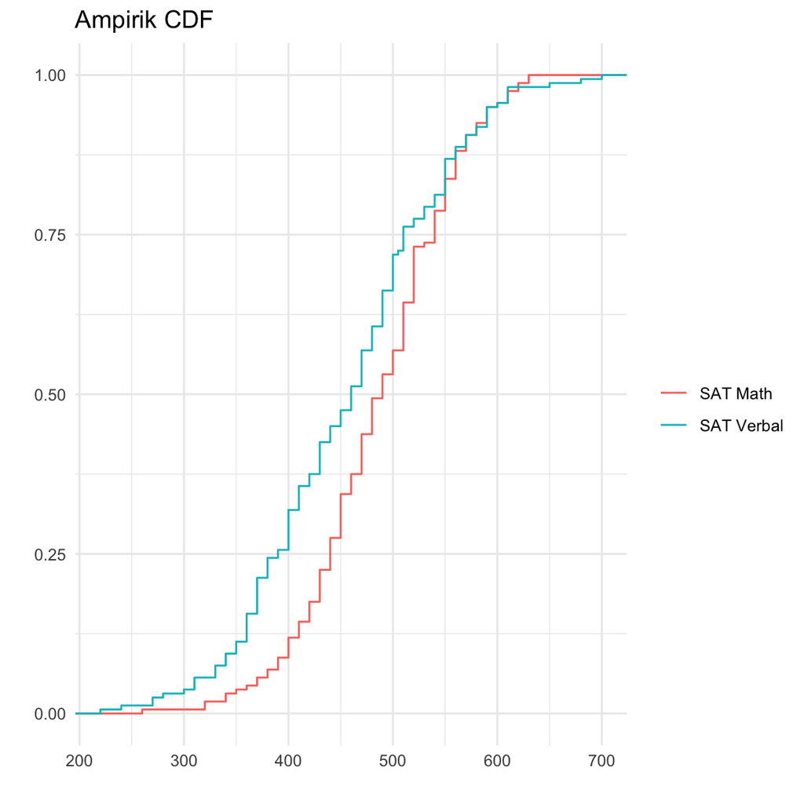

```r
dt %>%
  ggplot() +
  stat_ecdf(aes(val, color = var)) +
  labs(x = "", y = "", color = "",
       title = "Ampirik CDF") +
  theme_minimal()
```

Q-Q grafiği benzer şekilli dağılımları göstermekte, ancak kutu grafikleri merkezlerin farklı göstermekte. Sonuç olarak, kümülatif dağılım fonksiyonları o kadar benzer görünmüyor.

```r
ks.test(stud.recs$sat.m, stud.recs$sat.v)
```

```
##
##  Two-sample Kolmogorov-Smirnov test
##
## data:  stud.recs$sat.m and stud.recs$sat.v
## D = 0.2125, p-value = 0.001456
## alternative hypothesis: two-sided
```

Kolmogorov-Smirnov testi bunu tespit eder ve küçük bir p değeri döndürür. Küçük p değerinden örneklerin farklı dağılımlardan olduğu sonucuna varabiliriz.

# 2 ANOVA

Varyans analizi, ANOVA, ortalamadan sapmalara dayalı olarak örneklemler arasında ortalamaları karşılaştırma yöntemidir. ANOVA modeli, doğrusal modelin sadece özel bir şeklidir.

## 2.1 Tek Yönlü ANOVA

Tek yönlü varyans analizi, iki bağımsız örnek için t-testinin bir genellemesidir ve birkaç bağımsız örnek için popülasyon ortalamalarını karşılaştırmamızı sağlar.

Tek yönlü varyans analizinin amacı, örneklem ortalamalarındaki farkın popülasyon ortalamasındaki bir farklılığın göstergesi olup olmadığına veya örnekleme varyasyonuna atfedilebilir olup olmadığına karar vermektir.

Bu probleme bir anlamlılık testi olarak yaklaşılır.

Hipotezler

$$\begin{align}
H_0:&\ \mu_1 = \mu_2 = \cdots = \mu_k \\
HA:&\ \mu_i \neq \mu_j \quad \text{ en az bir i ve j ikilisi için}
\end{align}$$

şeklinde olsun.

Tek bir grup içindeki varyasyonları, gruplar arasındakilerle karşılaştıran bir test istatistiği oluşturulur.

$\bar{x}$ tüm veri setinin ortalaması ve $\bar{x_i}$ $i$inci örneklemin ortalaması olsun. Toplam kareler toplamı şu şekilde verilir:

$$\mathrm{SST} = \sum_i\sum_j\left( x_{ij} - \bar{x} \right)^2$$

Bu, tüm verilerin merkezinden itibaren varyasyon miktarını ölçer.

Varyans analizi, SST’yi iki toplama ayırır:

$$\mathrm{SST}=\sum_{i} \sum_{j}\left(x_{i j}-\bar{x}_{i}\right)^{2}+\sum_{i} n_{i}\left(\bar{x}_{i}-\bar{x}\right)^{2}$$

İlk toplam, karelerin hata toplamı veya SSE olarak adlandırılır.

İç toplam, $\sum_{j}\left(x_{i j}-\bar{x}_{i}\right)^{2}$ $i$inci grup içindeki değişimi ölçer.

SSE, grup içi değişkenliğin bir ölçüsüdür.

İkinci terime karelerin işlem toplamı (SSTr) denir.

SSTr, her grup için ortalamaları, $\bar{x_{i}}$, genel ortalama, ${x}, ile karşılaştırır. Örneklem ortalamaları arasındaki değişkenliği ölçer.

Denklemi şu şekilde yeniden ifade edebiliriz: $SST = SSE + SSTr$.

SSE ve SST çok farklıysa, sıfır hipotezine karşı kanıt olacaktır. Farklılıkların boş hipotezin yanlış olmasından mı yoksa sadece örneklem varyasyonundan mı kaynaklandığını nasıl anlayabiliriz? Her zamanki gibi, ayırt edebilecek bir test istatistiği bularak.

Tüm örneklemlerin eşit olup olmadığını test etmek için doğal bir test istatistiği, $SST − SSE = SSTr$ değerini dikkate almak olacaktır.

“Büyük” değerler, alternatif yönünde olacaktır. Bu karşılaştırmada F istatistiği kullanılır, ancak karelerin hata toplamına bölünür.

$$F=\frac{\mathrm{SSTr} /(k-1)}{\mathrm{SSE} /(n-k)}$$

Büyük değerler, ortalamalardaki farklılıkla hala tutarlıdır. Uygun ölçeği elde etmek için, her terim ilgili serbestlik derecelerine bölünerek ortalama kareler toplamını verir. Toplam kareler toplamının serbestlik derecesi $n - 1$ ’dır. SSE için serbestlik derecesi $n - k$, dolayısıyla SSTr için serbestlik derecesi $k - 1$’dır.

Verilerin normal olarak ortak ortalama ve varyansla dağıldığı varsayımına göre, bu istatistiğin bilinen bir dağılımı olacaktır: $k - 1$ ve $n - k$ serbestlik derecelerine sahip F dağılımı.

15 deneği rastgele üç gruba ayıralım. Her gruba bir ay atayalım. Her grup için rastgele seçilen bir günde tüketilen kalori miktarını kaydedelim. Tüketilen miktarların ortak varyansla, ancak farklı ortalamalarla **normal dağıldığını varsayalım**.

```r
calories <- tibble(may = c(2166, 1568, 2233, 1882, 2019),
                   sep = c(2279, 2075, 2131, 2009, 1793),
                   dec = c(2226, 2154, 2583, 2010, 2190)) %>%
  pivot_longer(everything(),
               names_to = "month",
               values_to = "cal")

calories %>%
  group_by(month) %>%
  summarise(mean_cal = mean(cal)) %>%
  bind_rows(tibble(month = "all", mean_cal = mean(calories$cal)))
```

```
## # A tibble: 4 × 2
##   month mean_cal
##   <chr>    <dbl>
## 1 dec      2233.
## 2 may      1974.
## 3 sep      2057.
## 4 all      2088.
```

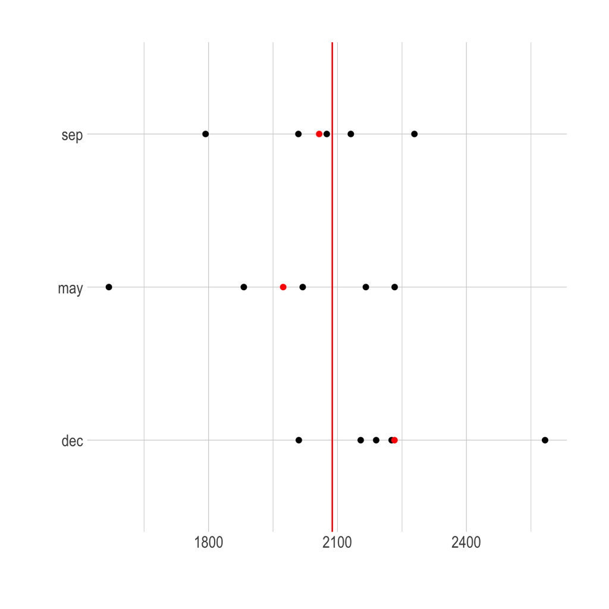

```r
calories %>%
  group_by(month) %>%
  ggplot() +
  aes(cal, month) +
  geom_point() +
  stat_summary(fun = mean, geom = "point", color = "red", fill = "red") +
  geom_vline(aes(xintercept = mean(calories$cal)), color = "red") +
  hrbrthemes::theme_ipsum() +
  labs(x = "", y = "")
```

Şekilden, tüm verilerin genel ortalamadan ziyade her ay için ortalamalar etrafında daha fazla kümelendiği görülmekte. Kışın belki de daha fazla kalori tüketilmektedir.

```r
oneway.test(cal ~ month, data = calories, var.equal = TRUE)
```

```
##
##  One-way analysis of means
##
## data:  cal and month
## F = 1.7862, num df = 2, denom df = 12, p-value = 0.2094
```

Anlamlı olmayan bir p değeri elde ederiz (0,05’ten büyük). Grafiksel kanıtlara rağmen, farklılıklar örnekleme varyasyonu ile makul bir şekilde açıklanabilir.

Alternatif `aov` fonksiyonu da bir varyans analizi gerçekleştirecektir.

```r
owaov <- aov(cal ~ month, data = calories)
tidy(owaov)
```

```
## # A tibble: 2 × 6
##   term         df   sumsq meansq statistic p.value
##   <chr>     <dbl>   <dbl>  <dbl>     <dbl>   <dbl>
## 1 month         2 174664. 87332.      1.79   0.209
## 2 Residuals    12 586720. 48893.     NA     NA
```

ANOVA testi önemlidir çünkü size grupların ortalamalarının farklı olup olmadığını söyler. Ancak test hangi grupların farklı olduğunu belirlemez ve farklılıklarını bildirmez.

`TukeyHSD()` veya `rstatix::tukey_hsd()` fonksiyonları bu farklılıkları hesaplayabilir ve en büyük olanları belirlemenize yardımcı olabilir.

```r
TukeyHSD(owaov)
```

```
##   Tukey multiple comparisons of means
##     95% family-wise confidence level
##
## Fit: aov(formula = cal ~ month, data = calories)
##
## $month
##           diff      lwr     upr     p adj
## may-dec -259.0 -632.094 114.094 0.1949625
## sep-dec -175.2 -548.294 197.894 0.4467189
## sep-may   83.8 -289.294 456.894 0.8231586
```

Çıktı tablosundaki her satır, iki grubun ortalamaları arasındaki farkı (diff) ve fark için güven aralığının alt ve üst (lwr ve upr) sınırlarını içerir.

Örneğin, tablodaki ilk satır “may” grubu ile “dec” grubunu karşılaştırır: ortalamalarının farkı -259’dur.

```r
tukey_hsd(owaov) %>%
  arrange(estimate)
```

```
## # A tibble: 3 × 9
##   term  group1 group2 null.value estimate conf.low conf.high p.adj p.adj.signif
##   <chr> <chr>  <chr>       <dbl>    <dbl>    <dbl>     <dbl> <dbl> <chr>
## 1 month dec    may             0   -259      -632.      114. 0.195 ns
## 2 month dec    sep             0   -175.     -548.      198. 0.447 ns
## 3 month may    sep             0     83.8    -289.      457. 0.823 ns
```

Tukey farklılıklarını çizmek için `ggiraphExtra::ggHSD()` fonsiyonunu kullanabiliriz.

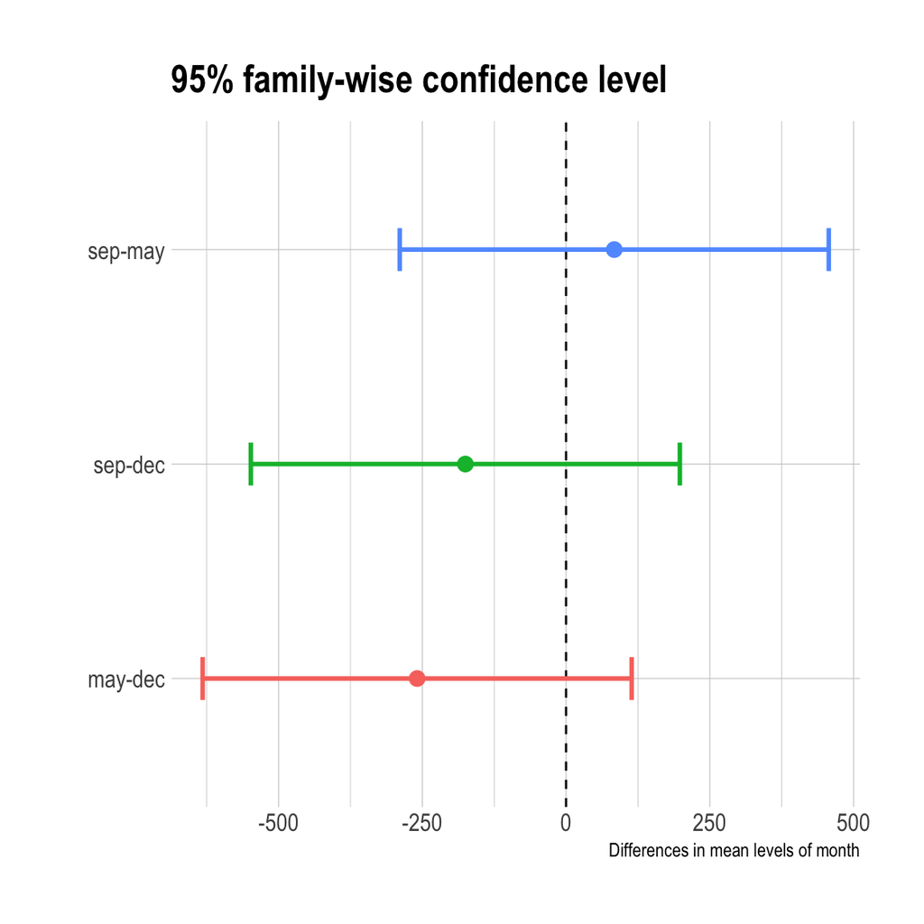

```r
TukeyHSD(owaov) %>%
  ggiraphExtra::ggHSD() +
  hrbrthemes::theme_ipsum()
```

Yatay çizgiler, her bir çift için güven aralıklarını gösterir. Bu görsel sunumla, güven aralıklarının sıfırın üzerinde kesiştiğini hızlı bir şekilde görebilirsiniz, bu da farkın önemli olmadığını gösterir.

## 2.2 İki Yönlü ANOVA

Nicel bir değişkenin ortalamasının iki kategorik değişkenin seviyelerine göre nasıl değiştiğini tahmin etmek için iki yönlü bir ANOVA kullanılır. İki bağımsız değişkenin kombinasyon halinde bağımlı bir değişkeni nasıl etkilediğini bilmek istediğinizde iki yönlü ANOVA kullanılabilir.

Aşağıdaki verileri kullanalım.

- `time`: Hayvanın hayatta kalma süresi
- `poison`: Kullanılan zehir türü
- `Treat`: Kullanılan tedavi türü

```r
dt <- read_csv("https://raw.githubusercontent.com/reddyprasade/Data-Science-With-R/master/Data/poisons.csv")

dt <- dt %>%
  select(-...1) %>%
  mutate(poison = factor(poison, ordered = TRUE))
```

Değişkenlerin kutu grafiğini kontrol edelim.

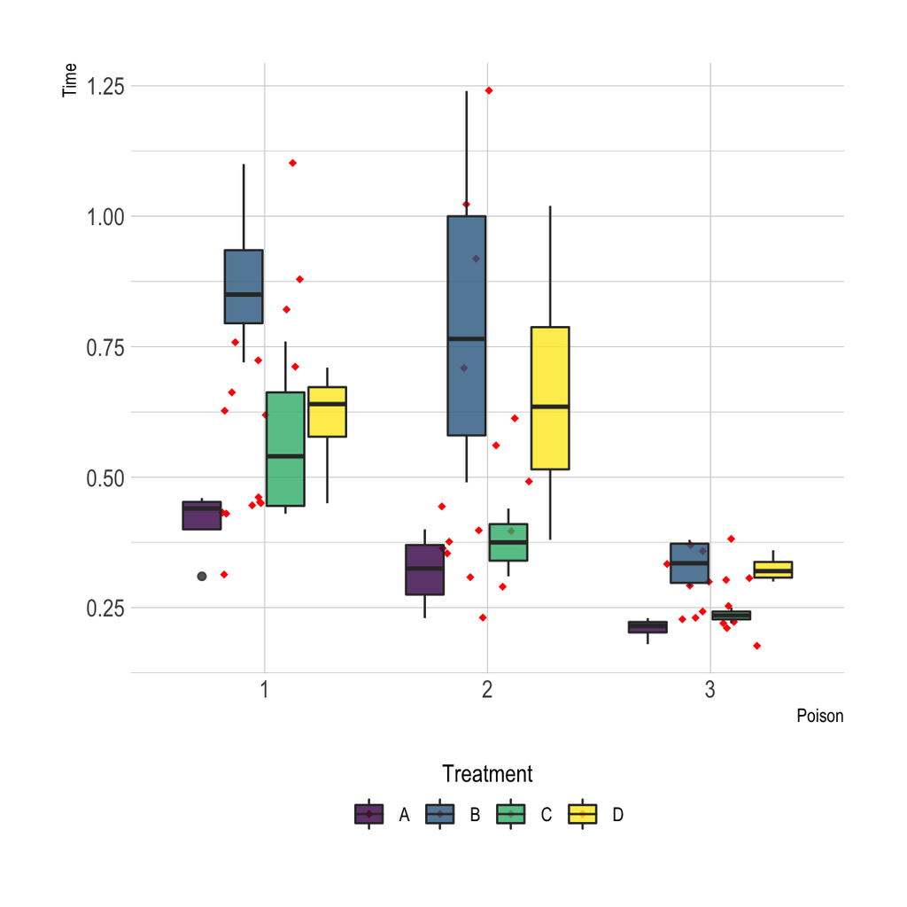

```r
dt %>%
  ggplot() +
  aes(x = poison, y = time, fill = treat) +
  geom_jitter(shape = 18,
              color = "red",
              position = position_jitter(0.21)) +
  geom_boxplot(alpha = 0.8) +
  scale_fill_viridis_d() +
  hrbrthemes::theme_ipsum() +
  labs(y = "Time", x = "Poison", fill = "Treatment") +
  guides(fill = guide_legend(title.position = "top")) +
  theme(legend.position = "bottom", legend.title.align = 0.5)
```

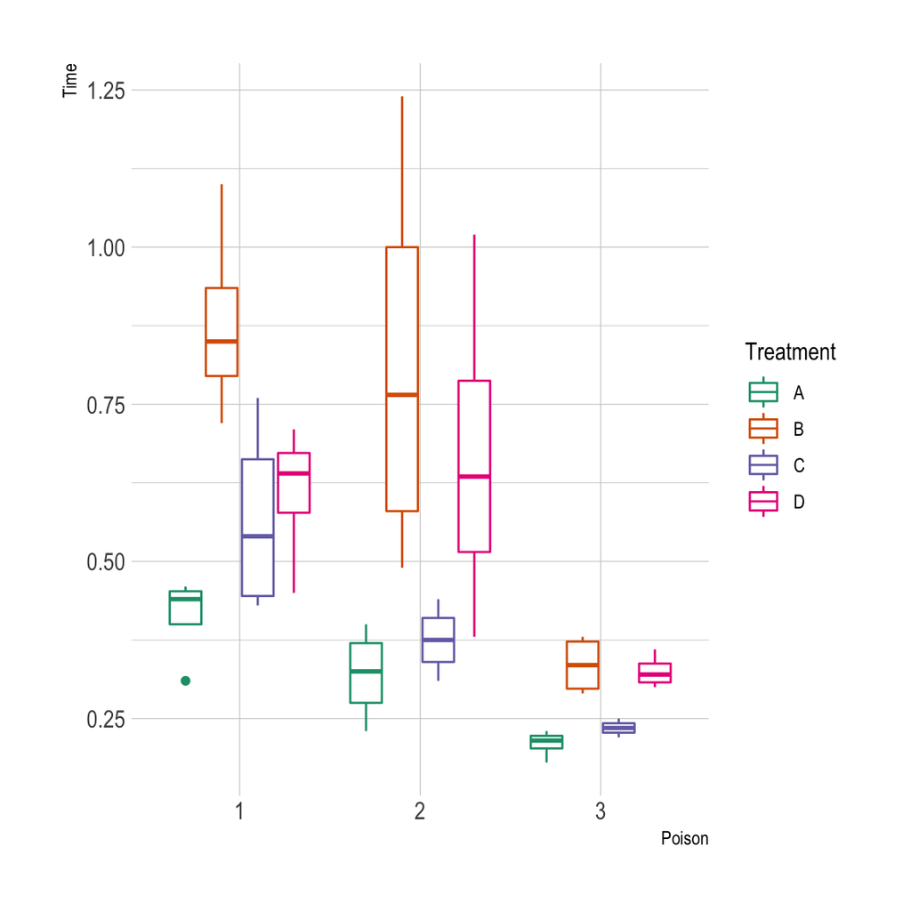

```r
ggpubr::ggboxplot(dt,
                  x = "poison",
                  y = "time",
                  color = "treat",
                  palette = "Dark2") +
  hrbrthemes::theme_ipsum() +
  labs(y = "Time", x = "Poison", color = "Treatment")
```

ANOVA tahmini yapalım.

```r
twaov <- aov(time ~ poison + treat, data = dt)

tidy(twaov)
```

```
## # A tibble: 3 × 6
##   term         df sumsq meansq statistic      p.value
##   <chr>     <dbl> <dbl>  <dbl>     <dbl>        <dbl>
## 1 poison        2 1.03  0.517       20.6  0.000000570
## 2 treat         3 0.921 0.307       12.3  0.00000670
## 3 Residuals    42 1.05  0.0250      NA   NA
```

p değerleri esasen sıfırdır, bu da ortalama sürenin gruplara bağlı olarak önemli ölçüde değiştiğini gösterir.

## 2.3 Robust ANOVA (Kruskal–Wallis Testi)

Verilerinizdeki grupların normal olarak dağılmadığını, ancak dağılımlarının benzer şekillere sahip olduğunu varsayalım. ANOVA’ya benzer bir test yapmak istediğimizi -grup medyanlarının önemli ölçüde farklı olup olmadığını bilmek istiyorunuz- düşünelim.

Normal ANOVA, verilerin normal bir dağılıma sahip olduğunu varsayar. Normallikten bir miktar sapmaya tahammül edebilir, ancak aşırı sapmalar anlamsız p değerleri üretecektir.

Kruskal-Wallis testi, ANOVA’nın parametrik olmayan bir versiyonudur, yani normalliği varsaymaz. Bununla birlikte, aynı şekilli dağılımları varsayar. Veri dağılımının normal olmadığı veya bilinmediği durumlarda Kruskal-Wallis testi kullanılmalıdır.

Boş hipotez, tüm grupların aynı medyana sahip olmasıdır. Boş hipotezin reddedilmesi (p < 0.05) tüm grupların farklı olduğunu göstermez, ancak iki veya daha fazla grubun farklı olduğunu gösterir.

```r
data("airquality")
glimpse(airquality)
```

```
## Rows: 153
## Columns: 6
## $ Ozone   <int> 41, 36, 12, 18, NA, 28, 23, 19, 8, NA, 7, 16, 11, 14, 18, 14, …
## $ Solar.R <int> 190, 118, 149, 313, NA, NA, 299, 99, 19, 194, NA, 256, 290, 27…
## $ Wind    <dbl> 7.4, 8.0, 12.6, 11.5, 14.3, 14.9, 8.6, 13.8, 20.1, 8.6, 6.9, 9…
## $ Temp    <int> 67, 72, 74, 62, 56, 66, 65, 59, 61, 69, 74, 69, 66, 68, 58, 64…
## $ Month   <int> 5, 5, 5, 5, 5, 5, 5, 5, 5, 5, 5, 5, 5, 5, 5, 5, 5, 5, 5, 5, 5,…
## $ Day     <int> 1, 2, 3, 4, 5, 6, 7, 8, 9, 10, 11, 12, 13, 14, 15, 16, 17, 18,…
```

Veriler, Mayıs-Eylül 1973’te New York’taki günlük hava kalitesi ölçümlerini göstermektedir. Ozon yoğunluğu, `ozone` sütununda yer almaktadır.

Verilerin normal dağılıma sahip olduğunu varsaymadan, New York’taki aylık ozon yoğunluğunun Mayıs’tan Eylül 1973’e kadar aynı veri dağılımlarına sahip olup olmadığını test edelim.

```r
kruskal.test(Ozone ~ Month, airquality)
```

```
##
##  Kruskal-Wallis rank sum test
##
## data:  Ozone by Month
## Kruskal-Wallis chi-squared = 29.267, df = 4, p-value = 6.901e-06
```

```r
rstatix::kruskal_test(airquality, Ozone ~ Month)
```

```
## # A tibble: 1 × 6
##   .y.       n statistic    df         p method
## * <chr> <int>     <dbl> <int>     <dbl> <chr>
## 1 Ozone   153      29.3     4 0.0000069 Kruskal-Wallis
```

Boş hipotez, aylık ozon yoğunluğunun aynı popülasyonlar olduğudur. p-değeri neredeyse sıfır çıkmaktadır (6.901e-06). Dolayısıyla boş hipotezi reddediyoruz.

# 3 Doğrusal Regresyon

[Sıradan En Küçük Kareler Regresyonu](https://setosa.io/ev/ordinary-least-squares-regression/)

$x$ ve $y$ gibi, $(x_1, y_1), (x_2, y_2), \cdots, (x_n, y_n)$ şeklinde gözlem ikililerine sahip vektörlerimiz olsun. $x$ ve $y$ arasında doğrusal bir ilişki olduğunu düşündüğümüzü ve bu ilişki için regresyon modeli kurmak istediğimizi varsayalım.

Basit doğrusal regresyon iki değişken içerir: genellikle $x$ olarak adlandırılan bir kestirici (veya bağımsız) değişken ve genellikle $y$ olarak adlandırılan bir yanıt (veya bağımlı) değişken.

Regresyon, sıradan en küçük kareler (OLS) algoritması ile doğrusal modeli tahmin eder:

$$y_i = \beta_0 + \beta_1x_i +\varepsilon_i$$

$\beta_0$ ve $\beta_1$ regresyon katsayıları ve $\varepsilon_i$ hata terimleri olarak adlandırılır.

```r
# ?moderndive::evals

data(evals, package = "moderndive")

dt <- evals %>%
  select(ID, score, bty_avg, age)

glimpse(dt)
```

```
## Rows: 463
## Columns: 4
## $ ID      <int> 1, 2, 3, 4, 5, 6, 7, 8, 9, 10, 11, 12, 13, 14, 15, 16, 17, 18,…
## $ score   <dbl> 4.7, 4.1, 3.9, 4.8, 4.6, 4.3, 2.8, 4.1, 3.4, 4.5, 3.8, 4.5, 4.…
## $ bty_avg <dbl> 5.000, 5.000, 5.000, 5.000, 3.000, 3.000, 3.000, 3.333, 3.333,…
## $ age     <int> 36, 36, 36, 36, 59, 59, 59, 51, 51, 40, 40, 40, 40, 40, 40, 40…
```

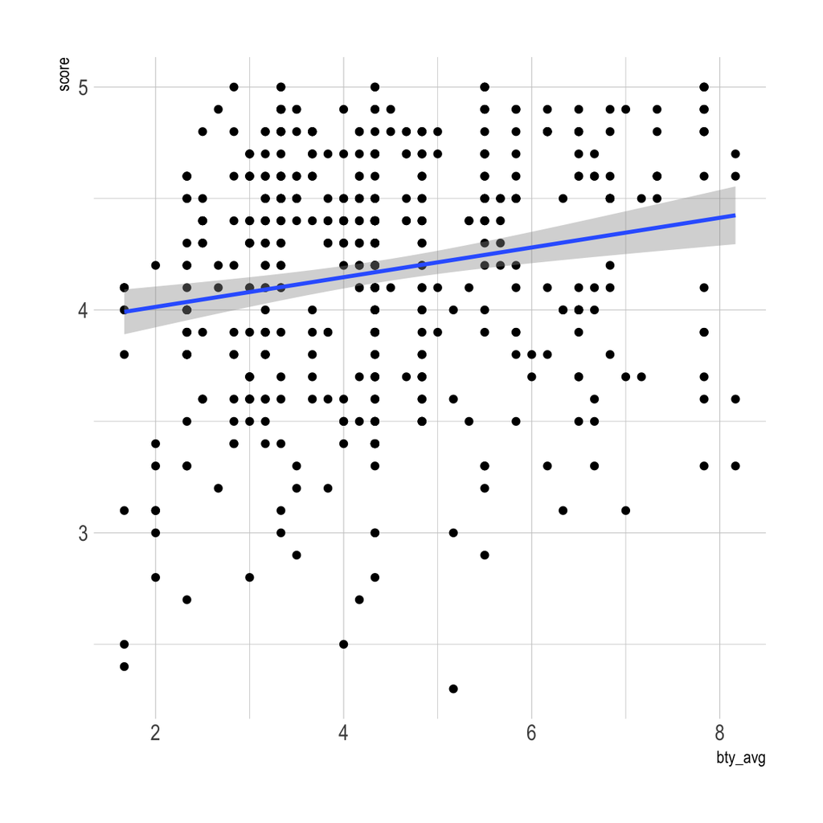

```r
dt %>%
  ggplot(aes(bty_avg, score)) +
  geom_point() +
  geom_smooth(method = "lm") +
  hrbrthemes::theme_ipsum()
```

```r
score_mod <- lm(score ~ bty_avg, data = dt)

summary(score_mod)
```

```
##
## Call:
## lm(formula = score ~ bty_avg, data = dt)
##
## Residuals:
##     Min      1Q  Median      3Q     Max
## -1.9246 -0.3690  0.1420  0.3977  0.9309
##
## Coefficients:
##             Estimate Std. Error t value Pr(>|t|)
## (Intercept)  3.88034    0.07614   50.96  < 2e-16 ***
## bty_avg      0.06664    0.01629    4.09 5.08e-05 ***
## ---
## Signif. codes:  0 '***' 0.001 '**' 0.01 '*' 0.05 '.' 0.1 ' ' 1
##
## Residual standard error: 0.5348 on 461 degrees of freedom
## Multiple R-squared:  0.03502,    Adjusted R-squared:  0.03293
## F-statistic: 16.73 on 1 and 461 DF,  p-value: 5.083e-05
```

```r
tidy(score_mod)
```

```
## # A tibble: 2 × 5
##   term        estimate std.error statistic   p.value
##   <chr>          <dbl>     <dbl>     <dbl>     <dbl>
## 1 (Intercept)   3.88      0.0761     51.0  1.56e-191
## 2 bty_avg       0.0666    0.0163      4.09 5.08e-  5
```

Bu örnekte, regresyon denklemi

```r
equatiomatic::extract_eq(score_mod, use_coefs = TRUE)
```

$$\operatorname{\widehat{score}} = 3.88 + 0.07(\operatorname{bty\_avg})$$